# A case study in logistic regression and cross-validation

First, a simple table of the counts and the means.

```r
# Produce summary statistics by group

alc %>% group_by(high_use) %>% summarise(count=n(),mean_goout=mean(goout))
```

```
## # A tibble: 2 x 3
##   high_use count mean_goout
##   <lgl>    <int>      <dbl>
## 1 FALSE      259       2.85
## 2 TRUE       111       3.73
```

We see that the sample mean for ‘’going out with friends’’ is clearly higher in the category of those with high alcohol consumption, as we hypothesized it would be. The mean does not tell much of the overall distribution, so let us take a look at a visual that can do that.

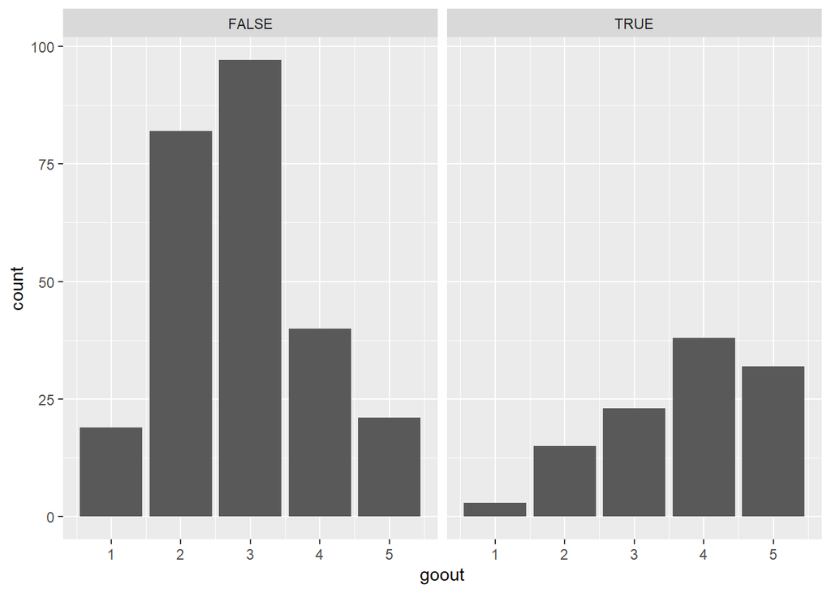

```r
# We require library ggplot2 for the visuals
library(ggplot2)

# Initialize a plot of 'high_use'
g <- ggplot(data = alc, aes(x=goout))

# Draw a bar plot of high_use by plan to attend higher education
g<-g + geom_bar()

# add the higher education plan dichotomy
g + facet_wrap("high_use")
```

We may observe that the bar-plots have opposite ‘’skews’‘: those that fall within the’‘high consumption’’ group have more of the high values of ‘’going out with friends’‘; while those in the’‘not-high consumption’’ group have more of the low values.

So our data is aligned with our hypothesis, yet again. We also observe, however, that we ought perhaps not treat our integer-valued and ordinal ‘’going out with friends’’ -predictor as if it were interval-valued in our model, since a unit increase in our predictor does not seem to have a consistent multiplicative effect on the odds of our outcome event of interest.

We print the table for the counts to back up our visual and the conclusions from it.

```r
# Produce proportions of high-alcohol use by planning to attend higher education

table(high_use=alc$high_use, goout=alc$goout) %>% addmargins()
```

```
##         goout
## high_use   1   2   3   4   5 Sum
##    FALSE  19  82  97  40  21 259
##    TRUE    3  15  23  38  32 111
##    Sum    22  97 120  78  53 370
```

We could pretty much lump the predictor categories 1,2 and 3 into a single category, and keep the 4 and 5 as the other two in our newly introduced trichotomy. This would reduce some of the information we have, though, since the categories 1,2 and 3 are not strictly speaking on par. It is best to treat the predictor as a factor, so we add it to our data and use it as a factor instead as numeric in our model.

```r
# Add goout as factor
alc <- mutate(alc, goout_fac=as.factor(goout))
```

Finally, we take a look at our ‘’family relations’’ variable and its relation with our dichotomous outcome of interest.

```r
# Produce summary statistics by alcohol consumption dichotomy

alc %>% group_by(high_use) %>% summarise(count=n(),mean_famrel=mean(famrel))
```

```
## # A tibble: 2 x 3
##   high_use count mean_famrel
##   <lgl>    <int>       <dbl>
## 1 FALSE      259        4.01
## 2 TRUE       111        3.77
```

We observe that the mean of our ‘’family relations’’ variable is lower for those falling in the ‘’high alcohol consumption’’ group, as we hypothesized. Let’s take a look at the bar plot to display the distribution partitioned by our alcohol consumption dichotomy.

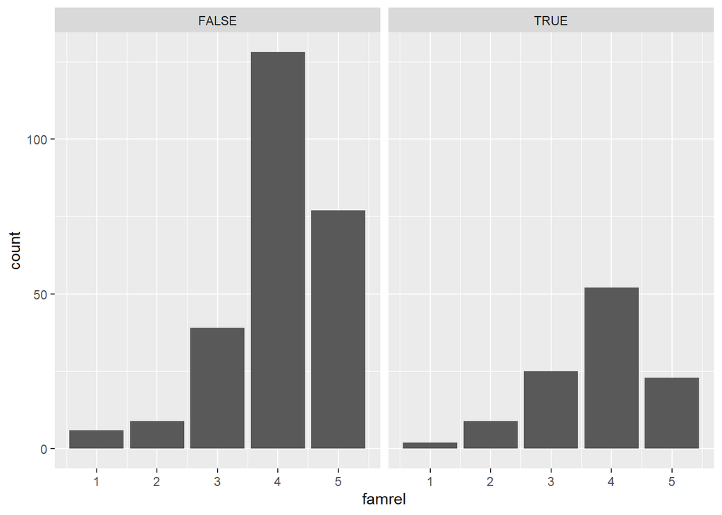

```r
# We require library ggplot2 for the visuals
library(ggplot2)

# Initialize a plot of 'high_use'
g <- ggplot(data = alc, aes(x=famrel))

# Draw a bar plot of high_use by plan to attend higher education
g<-g + geom_bar()

# add the higher education plan dichotomy
g + facet_wrap("high_use")
```

These look quite similar in terms of their shape, if not the absolute counts.

```r
# Produce proportions of high-alcohol use by planning to attend higher education

table(high_use=alc$high_use, famrel=alc$famrel) %>% addmargins()
```

```
##         famrel
## high_use   1   2   3   4   5 Sum
##    FALSE   6   9  39 128  77 259
##    TRUE    2   9  25  52  23 111
##    Sum     8  18  64 180 100 370
```

We may observe that our class with a value of 1 for family relations is very small, so we decide to combine it with the class that have a value of 2. We further turn the variable into a factor, as we did in the previous, for similar reasons as in the previous.

Note that we have not turned the factor into an *ordered* factor. So our logistic regression will not treat it as if it were ordinal, but as if it were categorical. By so doing, we fail to account for some of the inherent structure in our dataset. Yet we allow each coefficient of a factor level to be interpreted relative to the baseline level of that factor.

```r
# Recode famrel so that we combine values 1 and 2 into a value of 1
alc<- mutate(alc, famrel=recode(famrel, '1'=1, '2'=1, '3'=2, '4'=3,'5'=4))
alc<- mutate(alc, famrel_fac=as.factor(famrel))
```

We note that it would usually be good to explore the multidimensional relationships between the predictors and the outcome variable prior to regression modeling. However, since we treat none of our predictors as numeric, our multidimensional visuals tend to become disorderly. Thus we settle for these and proceed to modeling.

Logistic regression is a generalized linear model that uses the logit as its link function.

This means that we would have the following form for our logistic regression model with four predictor variables:

$\log({\frac{p}{1-p}})=b_0 + b_1x_1 + b_2x_2 + b_3x_3 + b_4x_4$,

*if we did not utilize factor variables*, as we of course exclusively do. In our case, each level of a factor, except the baseline level of the factor, is equipped with its own regression coefficient. The logit link function is handy in terms of the intuitive interpretation it offers for the exponential of the regression coefficient estimate as the *odds ratio*. This means that, a unit increase in the predictor variable, say $x_1$, is associated with $b_1$-fold increase in the odds, $\frac{p}{1-p}$, of the event. In our case the event of interest is ‘’high alcohol consumption’‘, and each $\exp(b)$, is comparative with respect to the baseline level of its factor. R in essence dummy-codes our factor levels for us so that’‘a unit increase’’ amounts simply to a shift from the baseline level of the factor to the level of the predictor that our regression coefficient denotes. So if, say, $\exp(b_4)=2$, then the odds of ‘’high alcohol consumption’’ are two-fold for $x_4$ relative to its baseline level.

```r
# find the model with glm()
m <- glm(high_use ~ famrel_fac + goout_fac + higher + sex, data = alc, family = "binomial")

summary(m)
```

```
##
## Call:
## glm(formula = high_use ~ famrel_fac + goout_fac + higher + sex,
##     family = "binomial", data = alc)
##
## Deviance Residuals:
##     Min       1Q   Median       3Q      Max
## -1.6032  -0.7657  -0.4871   0.8374   2.4355
##
## Coefficients:
##             Estimate Std. Error z value Pr(>|z|)
## (Intercept)  -1.4079     0.9512  -1.480 0.138816
## famrel_fac2   0.1560     0.5486   0.284 0.776196
## famrel_fac3  -0.6005     0.4997  -1.202 0.229496
## famrel_fac4  -1.1184     0.5374  -2.081 0.037421 *
## goout_fac2    0.1217     0.6960   0.175 0.861195
## goout_fac3    0.4448     0.6774   0.657 0.511360
## goout_fac4    1.9576     0.6760   2.896 0.003781 **
## goout_fac5    2.3721     0.7000   3.389 0.000702 ***
## higheryes    -0.5082     0.5993  -0.848 0.396415
## sexM          1.0122     0.2650   3.820 0.000134 ***
## ---
## Signif. codes:  0 '***' 0.001 '**' 0.01 '*' 0.05 '.' 0.1 ' ' 1
##
## (Dispersion parameter for binomial family taken to be 1)
##
##     Null deviance: 452.04  on 369  degrees of freedom
## Residual deviance: 369.89  on 360  degrees of freedom
## AIC: 389.89
##
## Number of Fisher Scoring iterations: 4
```

We note that we have the correct amount of regression coefficient estimates, one less for each factor variable than the amount of the levels it has. The baseline for ‘’family relations’’ is the level ‘’1’‘, which denotes’‘very bad’’ or ‘’bad’’ family relations. The baseline for ‘’going out with friends’’ is also ‘’1’‘, which denotes a’‘very low’’ value. The baseline for planning to go attend higher education is not planning to attend, and the baseline for male sex is female sex. We note that only a few of the levels have a statistically significant regression coefficient estimate associated with them. These are ‘’family relations’’ with value ‘’excellent’‘; going out with values’‘high’’ and ‘’very high’’, as well as the male sex. For all of these, the order is as had been hypothesized: the first in the list decreasing the odds of high consumption, the following three increasing it, *when holding all of the other predictors in the model constant*.

But before interpreting the regression coefficient estimates, we should exponentiate these, so that we may utilize the ease of the odds-ratio interpretation. We also derive the 95% confidence intervals for the exponentials of the coefficient estimates (the odds ratios attached to each predictor).

```r
# find the model with glm()
m <- glm(high_use ~ famrel_fac + goout_fac + higher + sex, data = alc, family = "binomial")

# compute odds ratios (OR)
OR <- coef(m) %>% exp

# compute confidence intervals (CI)
CI <- confint(m) %>% exp
# print out the odds ratios with their confidence intervals
cbind(OR, CI)
```

```
##                     OR      2.5 %     97.5 %
## (Intercept)  0.2446487 0.03352111  1.4692192
## famrel_fac2  1.1687773 0.40156995  3.4931207
## famrel_fac3  0.5485248 0.20690197  1.4884929
## famrel_fac4  0.3268105 0.11343518  0.9447502
## goout_fac2   1.1294034 0.31969632  5.3336017
## goout_fac3   1.5602481 0.46358899  7.1849404
## goout_fac4   7.0825545 2.12129236 32.6071661
## goout_fac5  10.7203751 3.04383540 51.1754486
## higheryes    0.6015482 0.18026784  1.9500032
## sexM         2.7515313 1.64749202  4.6669774
```

So an OR of 1 means that the odds are pretty much on par relative to the comparator of the baseline level. We notice that, as of course roughly should be, the predictors we found to be statistically significant with a two-sided test of the null of ‘’nil association’’ (here OR of 1) in the above, are the ones the confidence interval of which does not contain the value 1. For ‘’famrel_fac4’’ the upper bound is below 1 (indicating a decrease in odds comparative to the baseline); for ‘’goout_fac4’’ and ‘’goout_fac5’’ the lower bounds are above 1 (indicating an increase in odds comparative to the baseline); as it is for the male sex (indicating an increase in odds of the event in comparison to the baseline provided by the female sex).

We infer that our best point estimate is that ‘’excellent’’ family relations decrease the odds of high alcohol consumption by a multiplicative factor of 0.3. in comparison to the baseline of ‘’bad’’ or ‘’very bad’’ relations (when other predictors in the model our held constant). Our associated interval estimate with a 95% confidence level is from roughly a 0.1 to a 0.9 -fold decrease in odds.

Our best estimate for a ‘’high’’ value provided for ‘’going out with friends’’ is that this is associated with roughly a 7-fold increase in odds in comparison to the baseline of a ‘’very low’’ value (when other predictors in the model our held constant), and that we are 95% confident that the odds ratio is between roughly 2 and 32. For a value of ‘’very high’’, we have similar numbers of 10, 3, and 51, respectively.

Being male is associated with roughly a 2.7-fold increase in the odds of high alcohol consumption in comparison to women (when other predictors in the model our held constant). We are 95% confident that the male sex is associated with a 1.6 to 4.7-fold increase in the odds of high alcohol consumption.

Our point estimate for the OR of planning to attend higher education suggests that the odds of high alcohol consumption are decreased 0.6-fold in comparison to the baseline of planning not to attend. However, with the small number of observations in the reference group, we have a wide confidence interval, and cannot reject the null of an OR of 1, as its truve value might very well be as high as roughly 2. However, we note that this issue deserves further study, since the point estimate is suggestive of a substantive association.

We will end by making predictions based on our model. We include all our predictor variables in the model, even though planning to attend higher education fails to have a statistically significant regression coefficient estimate, since it nonetheless is likely to increase our predictive power (even if only a little). We will also plot the confusion matrix to assess performance.

```r
# Fit the model
m <- glm(high_use ~ famrel_fac + goout_fac + higher + sex, data = alc, family = "binomial")

# Predict() the probability of high_use
probabilities <- predict(m, type = "response")

library(dplyr)
# add the predicted probabilities to 'alc'
alc <- mutate(alc, probability = probabilities)

# use the probabilities to make a prediction of high_use
alc <- mutate(alc, prediction = probability > 0.5)

# see the last ten original classes, predicted probabilities, and class predictions
select(alc, failures, absences, sex, high_use, probability, prediction) %>% tail(10)
```

```
## # A tibble: 10 x 6
##    failures absences sex   high_use probability prediction
##       <dbl>    <dbl> <chr> <lgl>          <dbl> <lgl>
##  1        0        3 M     FALSE         0.257  FALSE
##  2        1        0 M     FALSE         0.201  FALSE
##  3        1        7 M     TRUE          0.171  FALSE
##  4        0        1 F     FALSE         0.0698 FALSE
##  5        0        6 F     FALSE         0.112  FALSE
##  6        1        2 F     FALSE         0.0515 FALSE
##  7        0        2 F     FALSE         0.364  FALSE
##  8        0        3 F     FALSE         0.128  FALSE
##  9        0        4 M     TRUE          0.813  TRUE
## 10        0        2 M     TRUE          0.182  FALSE
```

```r
# tabulate the target variable versus the predictions
table(high_use = alc$high_use, prediction = alc$prediction)
```

```
##         prediction
## high_use FALSE TRUE
##    FALSE   240   19
##    TRUE     57   54
```

We can see from the confusion matrix that we are able to predict the non-cases (not-high alcohol consumption) rather well, which is not surprising, given the we have an initial setting of a class imbalance, with 70% of the observations non-cases. Out of these, we are able to predict $\frac{240}{259}\sim 0.92$ (this is the specificity of our classifier). Of the cases, though, we are able to predict only but roughly half (this is the sensitivity of our classifier). Overall, our prediction accuracy, i.e. the proportion of correct predictions is: $\frac{240+54}{370}\sim 0.795$. A baseline model with no predictors would be able to achieve accuracy of $0.7$ by guessing all observations to be ‘’non-cases’’ (not-high alcohol consumption). A simple statistical test can be used to assess whether our model is significantly better in comparison to this null model, but it is clear that it is even without the test. More important is whether our model is good enough to be useful, and this depends on the use to which our model is to be put. One could already claim that, in general, the increase in accuracy achieved by our model in comparison to the baseline is modest, but could still prove useful.

Our model has been fitted and assessed on the entire dataset in the above. This means that we have likely overfitted the model, and its performance on a test dataset that the model has not been trained on would be lower than what we observed on the training dataset alone. To guard one from overfitting, one should use cross-validation techniques. Here, one would be well advised to first split the data into a training and a test dataset (the latter could comprise of, say, 20% of the observations). Then, one would conduct cross-validation on the training dataset, for instance, by leaving aside some proportion of the training set for validation on each iteration on which one trains the model by tuning its parameters to optimize performance on a chosen criterion. One would loop through such iterations, by taking a different partitioning into training and validation on each iteration. In each of these iterations, the model would be assessed in the validation dataset, its performance stored, and at the end of all of the iterations, a summary of the performance (usually just the mean performance) across the iterations would be provided. One would then choose the best model on the basis of this aggregare performance measure, and, finally, evaluate that model against the test (‘’holdout’’) dataset which we had initially set aside to ensure that performance be assessed truthfully on a dataset the model had not seen in its training phase.

Now in such a development one would have a collection of classifiers and, of course, simple logistic regression would tend not to prevail as the best performing method (although, its extention to an elastic net penalty found in the glmnet package is already often rather good). Furthermore, accuracy is rarely a good performance criterion to use when training the model, especially in the case of a class imbalanced classifier, since we should usually like our model to be able to detect the cases. In general, this is just to say that the loss function should not be 0-1 off-the-shelf, so that one accrues a penalty of 1 for each ‘’miss’’ regardless of its type (and zero for a correct prediction). One ought instead construct a loss function that accounts for the context of the use of the model, and in such context, it is invariably the case that some types of errors are more costly than others (such as the false negatives in comparison to the false positives – just think of a case where our classifier is a diagnostic device aiming to detect the presense of a disease). Since one always trades off sensitivivity with specificity, a good standard performance measure for a classifier is often the area under the ROC-curve (AUC). After having trained and optimized the classifier in terms of AUC, one may then proceed to choose an appropriate detection level (a probability threshold) for classifying a case as such. This threshold could then be chosen so as to account for the losses attached to the different types of errors in the use context.

We may encode our 0-1 loss for the predictions (penalizing 0 in the case of a correct prediction and 1 in case of an incorrect one) as below and observe that our loss is the proportion of incorrect predictions: a value which is the negation of the accuracy of our model we calculated in the above.

```r
# Define a loss function (mean prediction error)
loss_func <- function(class, prob) {
  n_wrong <- abs(class - prob) > 0.5
  mean(n_wrong)
}

# call loss_func to compute the average number of wrong predictions in the (training) data


# This is the proportion of wrong predictions
loss_func(class = alc$high_use, prob = alc$probability)
```

```
## [1] 0.2054054
```

We may conduct 10-fold cross validation (where on each iteration a different 10% of the training data is used for validation) of our model and assess overall performance with the following code, utilizing the boot-library.

```r
# define a loss function (average prediction error)
loss_func <- function(class, prob) {
  n_wrong <- abs(class - prob) > 0.5
  mean(n_wrong)
}

# compute the average number of wrong predictions in the (training) data


# K-fold cross-validation
library(boot)
cv <- cv.glm(data = alc, cost = loss_func, glmfit = m, K = 10)

# average number of wrong predictions in the cross validation
cv$delta[1]
```

```
## [1] 0.2351351
```

We conlude that our model is decent at best, when evaluated with a loss-function (and a performance criterion) that is usually not the go-to choice. Our model outperforms a null model guessing a non-case each time (which would have accuracy of 0.7).

Note that we would still want to assess the performance of our classifier on a further never-seen-before dataset prior to concluding on final performance.